# Virginia Math Bulletin

**Virginia Math Bulletin**

Issue 5 Volume 1 Fall 2018

- Faculty News
- Department News & Activities
- Undergraduate News
- Community Outreach
- Graduate News

## Views from the Chairs

### Zoran Grujić, Professor of Mathematics, Interim Chair 2017-2018

Greetings friends, old and new. I am writing this after completing my

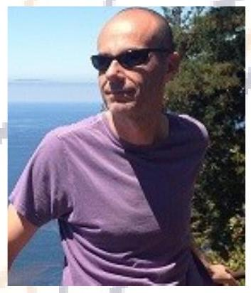

one year-term as the Interim Chair, happy to report that the Department is alive and well!

The stage set by Craig Huneke’s four-year term as the Chair was the one of a department in which the faculty and the students (graduate and undergraduate alike) were pursuing a variety of exciting avenues of the mathematical inquiry, a department committed to exploring new ways of how we teach mathematics (particularly Calculus) by adopting/redesigning a variety of student-centered, active learning methodologies, as well as a department fully engaged in outreach across the University, the Commonwealth and beyond; hence, it should come as no surprise that the academic year 2017-2018 was a productive one. A glimpse of what transpired can be gained from the rest of the newsletter, in what follows, I will just touch on several highlights.

Our Calculus transformation efforts initiated by Craig and spearheaded by Paul Bourdon received a boost this year by hiring James Rolf who previously served as Director of Quantitative Learning at Yale.

A number of our faculty members received national honors and awards; in particular, Karen Parshall received The Albert Leon Whiteman Memorial Prize of the AMS, Julie Bergner received The Ruth I. Michler Memorial Prize of the AWM, Nicholas Kuhn and Weiqiang Wang were inducted in the 2018 Class of the Fellows of AMS, and John Imbrie and Andrei Rapinchuk held their Simons Fellowships in Mathematics.

On the undergraduate side, Grace Dwyer, Kevin Lee and Luca Scerbo were inducted in Phi Beta Kappa and Sebastian Haney was awarded a Goldwater Scholarship. On the graduate side, Mariano Echeverria and Veronica Shalotenko were the recipients of All-University Graduate Teaching Awards and Mike Reeks received Class of 1985 Fellowship for Creative Teaching.

The Institute of Mathematical Sciences (IMS) experienced a flurry of activity, including two series of Virginia Mathematics Lectures, by Yair Minsky (Yale) in the Fall and Irene Fonseca (Carnegie Mellon) in the Spring, two IMS Special Lectures by Barry Simon (Caltech), an IMS Public Lecture (co-sponsored with Physics) by Jacob Sherson (Aarhus) on citizen science, as well as two workshops. In addition, the public lectures sponsored by the A&S Diversity and Inclusion Grant, awarded to Sara Maloni, sparked the interest of the broader University community; the lectures were given by Moon Duchin (Tufts), Abby Stewart (Michigan) and Henry Segerman (Oklahoma State), addressing the topics of mathematics of gerrymandering, changing departmental culture to be more inclusive, and artistic mathematics, respectively.

On a personal note, I am quite ready to go back to research and teaching as my favorite pastimes. The good news is that John Imbrie is here ready to take our department to the exciting new adventures.

### John Imbrie, Professor of Mathematics, Chair

I write this note as I begin a three-year term as chair. I am humbled by all that has been

[figure not shown]

accomplished in the department during the five years since my interim chairmanship in 2012-3: four years under Craig Huneke’s guidance, and last year with Zoran Grujić at the helm. There have been quite a few new faculty added over this timespan, and with these additions comes a feeling of anticipation and activity with the new term just around the corner. I know that we are all dedicated to making the department the best it can possibly be, by working as hard as we can to find excellence in new hires and new admissions, and by fostering a nurturing environment for newcomers and veterans alike.

The upcoming year will be a busy one, with a faculty search in the works, several promotions to attend to (a welcome and natural consequence of the hiring we have been doing), and continued expansion of calculus reform (with new faculty member James Rolf joining Paul Bourdon in that effort).

Readers of this newsletter series will see over the last few issues all the momentous changes and accomplishments over these years. My heartfelt thanks goes to Zoran for accepting the chair position during the last year. During this time, I was able to pursue a year of research leave in Princeton, developing exciting ideas and new collaborations that will keep me busy during lulls in department business — assuming there are any! His dedication to the department’s well-being has been evident from the beginning. I realize that every challenge he faced and surmounted during the last year makes my work that much easier. I only hope I can serve the department as well as Craig and Zoran have. With the efforts of our dedicated faculty, staff, and students, and with the support of the Dean’s office and alumni, I have every expectation for another banner year in Kerchof Hall.

## Supporting Us

The Mathematics Department is grateful for the generous support of its alumni and friends. The Department welcomes gifts annually to address its most urgent needs, as well as to the endowment which provides funding in perpetuity. To learn about how you can make a difference by supporting the Mathematics Department, please contact Liz Blaine at lblaine@virginia.edu or (434) 924-6156. To make a gift online, please visit http://giving.virginia.edu/mathematics

## New Faculty Profiles

### Benjamin Hayes, Assistant Professor (2017–)

Working with colleagues in the Department of Mathematics’ operator theory

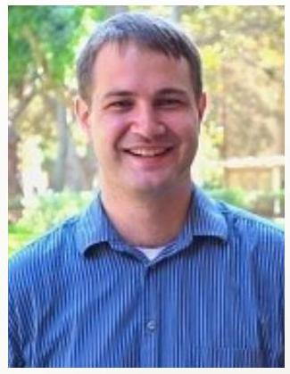

group, Benjamin Hayes researches topics involving the measurement of how many finitary approximations there are of a given infinitary object, including: entropy for actions of nonamenable groups, free probability with connections to von Neumann algebras and random matrices, and sofic groups.

Hayes arrives at the University of Virginia with a grant from the National Science Foundation’s Division of Mathematical Sciences for his continuing research. He has published nine papers, including articles in Geometric and Functional Analysis, International Mathematics Research Notices and Journal of the Institute of Mathematics Jussieu. As a graduate student at UCLA, Hayes earned a Dissertation Year Fellowship and the Heaviside Wealth Management Award, which recognizes the graduate student who does the best job explaining their research to someone outside of their field.

Hayes received his B.S. in mathematics from the University of Washington (2009) and earned his Ph.D. in mathematics from UCLA (2014).

Hayes will be teaching an Introductory Real Analysis course in the fall and Calculus on Manifolds in the spring. Excited to work with the department’s operator theory group, Hayes also plans to explore possible collaborations and connections with the department’s algebra and probability groups.

### Jim Rolf, Associate Professor (2018–)

Trained as a numerical analyst, James (Jim) Rolf currently focuses on the scholarship of teaching and

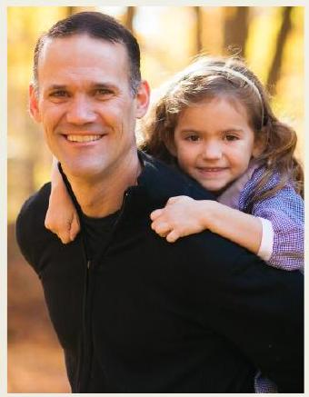

learning mathematics. He has published a number of articles and is a co-author of the book *Explorations in Complex Analysis*  
(Mathematical Association of America, 2012). His work has been supported by numerous grants funded by the Association of American Universities, the National Science Foundation; Microsoft Corporation, Yale’s Center for Teaching and Learning, and others.

Rolf received a Ph.D. from Duke University in 1997, a Master of Divinity from Southwestern Theological Seminary, and a bachelor’s of science from Baylor University. Before coming to the University of Virginia, he served as the Shizuo Kakutani Lecturer at Yale University, as an associate professor of mathematics at the United States Air Force Academy and as an assistant professor at the United States Military Academy at West Point.

Joining the Department of Mathematics, Rolf will teach Math 1320 (Integral Calculus) this next year and will help design metrics to assess changes in student learning and attitudes in this course when changes to course design are implemented.

He also will continue to work with other institutions as they seek to implement and assess innovative ways to help incoming students prepare for quantitative reasoning requirements at their institution.

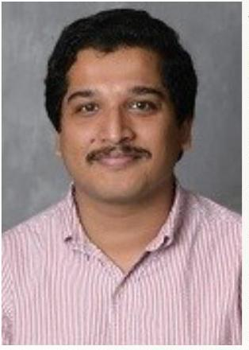

### Vivek Mukundan, Postdoctoral Fellow (2017–)

Working in the areas of commutative algebra and algebraic geometry, Vivek Mukundan’s research spans methods for computing the defining ideal of the Rees algebra, studying the invariants of powers of edge ideals, multiplicity theory, koszul algebras and other topics.

Vivek received his master’s degree in mathematics from the Indian Institute of Technology in Madras, India, and a Ph.D. in mathematics from Purdue University. Before coming to the University of Virginia, he was a visiting fellow at the Tata Institute of Fundamental Research in Mumbai, India.

Mukundan’s research grants and fellowships include multiple summer research grants from Purdue University, a National Board for Higher Mathematics postdoctoral fellowship from India’s Department of Atomic Energy, an INSPIRE Faculty Award from India’s Ministry of Science & Technology, a Jawaharlal Nehru Centre for Advanced Scientific Research Fellowship, and travel grants from the American Mathematical Society and the Mathematical Research Communities program.

At UVA, he plans on furthering his research in the fields of commutative algebra and algebraic geometry while expanding his teaching repertoire.

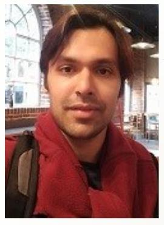

### Prasit Bhattacharya, Whyburn Instructor (2017–)

Working in the area of algebraic topology, Prasit Bhattacharya researches computational aspects of stable homotopy theory. Specifically, he explores stable homotopy groups of spheres, using chromatic homotopy theory. He studies $v_n$ self-maps that result in infinite families of elements in stable homotopy groups of spheres, and his current research involves $C_2$-equivariant computations, with a focus on the telescope conjecture.

Bhattacharya completed his bachelor’s degree (2007) and his master’s degree in mathematics (2009) at the Indian Statistical Institute in Bangalore, India. He completed his Ph.D. at Indiana University (2015). Bhattacharya comes to the University of Virginia from the University of Notre Dame, where he served as a visiting assistant professor (2015-2017).

Bhattacharya has taught mathematics courses at all college levels, including pre-calculus, calculus (at various levels), linear algebra and finite mathematics. He enjoys mentoring undergraduate students as well as high-school students. Bhattacharya hopes to continue mentoring students at UVA and to teach courses at various levels while organizing graduate-level seminars, as he has at previous institutions.

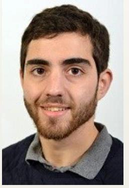

### Liron Speyer, Whyburn Instructor (2017–)

A postdoctoral researcher specializing in representation theory, Liron Speyer focuses his work on the study of a fundamental object known as the symmetric group, as well as several families of related mathematical objects. These include the quiver Hecke algebras introduced in the last decade, which have brought about a surge of interest in the area.

Liron will be joining the University of Virginia directly from Osaka University, Japan, where he held a postdoctoral fellowship funded by the Japan Society for the Promotion of Science. After receiving his Ph.D. in mathematical sciences from Queen Mary University of London, and his master’s degree in mathematics from the University of Warwick, he held a visiting postdoctoral position at the University of East Anglia, funded by the London Mathematical Society.

Liron’s work has been published in Transactions of The American Mathematical Society, Proceedings of The American Mathematical Society, International Mathematics Research Notices, as well as three top algebra journals.

This academic year, Liron will teach algebra courses for science majors, while his research will largely focus on constructing a vast generalization of the famous Littlewood-Richardson Rule in the context of quiver Hecke algebras.

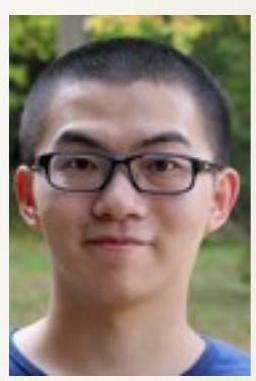

### Jinbo Ren, Postdoctoral Research Associate (2018–)

Working in the areas of number theory and algebraic geometry, Jinbo Ren’s research mainly concerns subjects on the arithmetic and geometric properties of abelian varieties and Shimura varieties, for example the André-Oort and Zilber-Pink conjectures. He also works in related topics in symmetric spaces, transcendental number theory, model theory, and group theory.

Jinbo received his master’s degree in mathematics from both Universiteit Leiden, the Netherlands and Université Paris-Sud, France. He completed his Ph.D. in mathematics from Université Paris-Sud, France. Before coming to the University of Virginia, he spent three years at Institut des Hautes Études Scientifiques (IHES), France.

Besides the pursuit of excellent mathematical research, Jinbo has a great passion for teaching. For him, each day with lectures is a holiday. He radiates an infectious enthusiasm in making everyone in his class enjoy the beauty of mathematics, instead of only coping with exams. Jinbo also takes classical literature as a pastime.

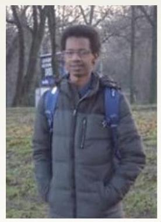

### Mouhamadou Sy, Postdoctoral Research Associate and Whyburn Lecturer (2017–)

Mouhamadou Sy attended high school in Mauritania, then joined the University of Cergy-Pontoise in France for his undergraduate and graduate studies.

In 2017, he received his PhD from the University of Cergy-Pontoise. His current research interests include Partial Differential Equations and Mathematical Physics. Recently, his work centers on his interest in the description of longtime behavior of some models that arise from fluid dynamics and relativistic quantum mechanics via the theory of invariant measures. This method employs statistical equilibria of systems to predict the individual behavior of their constitutive particles.

He also likes working with students in order to introduce them to different mathematical concepts and scientific thought. During his graduate studies at UCP, he supervised undergraduate students working on their final dissertations. In 2015, he received an award in recognition of this work from the FSPM (Mathematical Sciences Foundation of Paris), in collaboration with the Casden Bank.

At UVa, he plans to develop probabilistic methods to approach the Cauchy problem of supercritical equations - an outstanding open problem in the theory of Partial Differential Equations.

## Faculty Awards and Honors

### Karen Parshall Receives 2018 AMS Whiteman Prize

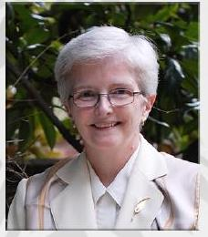

Commonwealth Professor of Mathematics and History Karen Hunger Parshall received the 2018 Albert Leon Whiteman Memorial Prize of the AMS for her outstanding work in the history of mathematics, and in particular, for her work on the evolution of mathematics in the USA and on the history of algebra, as well as for her substantial contribution to the international life of her discipline through students, editorial work, and conferences.

The Albert Leon Whiteman Memorial Prize recognizes notable exposition and exceptional scholarship in the history of mathematics. It was established in 1998 using funds donated by Mrs. Sally Whiteman in memory of her husband, Albert Leon Whiteman. The 2018 prize was awarded Thursday, January 11, 2018, at the Joint Mathematics Meetings in San Diego.

### Julie Bergner Receives Michler Memorial Prize

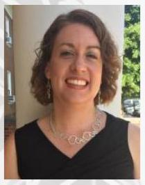

Associate Professor Julie Bergner has been selected as the winner of the 2018-2019 Ruth I. Michler Memorial Prize competition.

The Ruth I. Michler Memorial Prize of the AWM is awarded annually to a woman recently promoted to Associate Professor or an equivalent position in the mathematical sciences. The Ruth I. Michler Memorial Prize honors outstanding women at this stage of their careers and enables them to focus on their research in the stimulating environment of the Cornell University Mathematics Department.

A $47,000 prize will be awarded to a woman, recently promoted to associate professor or the equivalent, for a semester of mathematical research without teaching obligations in the Mathematics Department of Cornell University. A supplement housing/subsistence stipend award of $3,000 will be provided. Office space, library access, and computing facilities will be provided by Cornell. The award is to be used during the 2018-2019 academic year.

She was selected for her "proposed project to connect some of her recent work with the research of Cornell faculty member Inna Zakharevich, including simultaneous developments by both women (and their respective coauthors) on algebraic $K$-theory constructions." Bergner’s research has been in the areas of homotopy theory. Her proposed research will bring together several facets of her work: the theoretical framework of homotopical categories and generalizations, the realization of $2$-Segal spaces as a form of algebraic $K$-theory, and looking at derived Hall algebras as algebraic homotopical categories.

### Nicholas Kuhn and Weiqiang Wang Named 2018 AMS Fellows

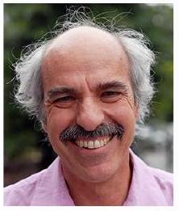

Professors Nicholas J. Kuhn and Weiqiang Wang have been named 2018 Fellows of the American Mathematical Society:

- Nicholas Kuhn “For contributions to homotopy theory, group cohomology and representation theory.”
- Weiqiang Wang “For contributions to Lie theory and representation theory and service to the mathematical community.”

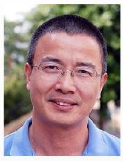

Sixty-three mathematical scientists have been named 2018 Fellows of the AMS. AMS President Kenneth A. Ribet says, "This year’s class of AMS Fellows has been selected from a large and deep pool of superb candidates. It is my pleasure and honor as AMS President to congratulate the new Fellows for their diverse contributions to the mathematical sciences and to the mathematics profession."

### Paul Bourdon Promoted to Full Professor

Paul Bourdon was promoted to Professor of Mathematics,

General Faculty this year. He came to UVa in 2013 as a Visiting Professor of Mathematics, having held appointments at Michigan State University, the University of Tennessee at Knoxville, and Washington & Lee University where he was Cincinnati Professor of Mathematics. Bourdon’s research interests are operator theory (especially composition operators acting on spaces of analytic functions), function theory (analytic & harmonic), and quantum-information theory (superdense coding with partially entangled quantum particles). His research has been supported through four grants and two research-opportunity awards from the National Science Foundation. Bourdon received, April 2000, the John Smith Award for Distinguished Teaching of Mathematics, conferred by the MD-VA-DC Section of the Mathematical Association of America. He is currently Director of Lower Division Courses for the Mathematics Department.

### Ben Hayes Awarded Excellence in Postdoctoral Research Prize

Assistant Professor of Mathematics Ben Hayes was awarded the Samir

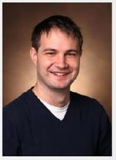

Aldroubi and Amira Azhari Prize for Excellence in Postdoctoral Research from Vanderbilt University on Wednesday, April 18, 2018.

The Samir Aldroubi and Amira Azhari Prize for Excellence in Postdoctoral Research is awarded every two years to recognize the research achievements of current and recent postdoctoral fellows in the department. It was established by Mathematics Professor Akram Aldroubi in honor of his parents, Samir Aldroubi and Amira Azhari. Candidates for the Aldroubi-Azhari Award are nominated by the faculty of the department, and the recipient is selected by a departmental committee. The chosen mathematician receives $\$ 1,000$ and is invited to Vanderbilt to deliver a mathematics colloquium reflecting his or her research interests.

## Transforming Calculus

By Paul Bourdon

> The course was challenging, but I learned a lot of new material in ways that were easier to understand and implement. I liked the "flipped" aspect of the class because I find that doing problems is the best way to learn mathematics. Overall, the course went well and I learned a lot. —Comment from a student’s course evaluation of "transformed" Calculus I (Math 1310)

In October of 2016, Mathematics Department faculty approved a proposal to transform calculus instruction at UVa by reducing class sizes, increasing the amount of time students spend in class engaged in problem-solving activities—especially group-based ones—and augmenting learning objectives for the course to include improvement of technical reading and writing skills as well as development of confidence and competence in communicating technical information orally.

The "Transforming Calculus" proposal, authored by Craig Huneke (Chair of the Department, 2013-2017), also calls for primary instructors to conduct all class meetings (those labeled "discussion" as well as those labeled "lecture"), adding a fourth hour of instruction in 1200-level calculus courses, creating new general-faculty and postdoctoral positions to provide additional instructors needed to support smaller class sizes and more hours of instruction per week, and expanding the Math Tutoring Center to increase support for calculus students outside of the classroom.

### Some Background

The Department offers a two-tier system of calculus instruction: a one-year sequence (1210-1220, A Survey of Calculus I-II) for students interested primarily in the life, managerial, and social sciences, and a one-year sequence (1310-1320, Calculus I-II) for students interested primarily in the natural sciences (including mathematics). In the Spring and Fall of 2015, 1742 students took 1210 or 1220 in 44 sections. During the same period, 514 students took 1310 or 1320 in 17 sections. A significant portion of all students in the College pass through these courses. Each course in the 1300-level sequence carries four credits, providing 200 minutes of class time per week, while currently each course in the 1200-level sequence carries three credits, providing 150 minutes of instruction per week.

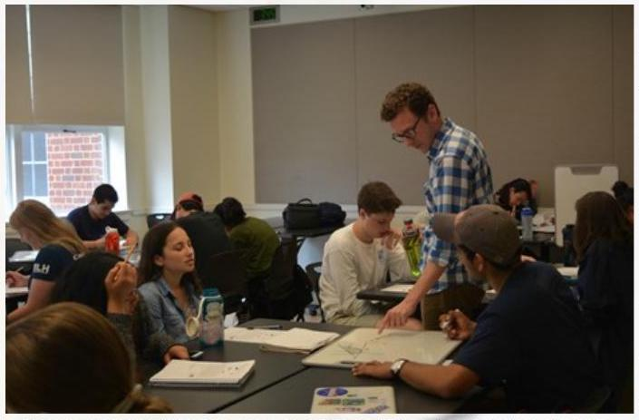

Instructor Jon Simone responds to a student’s question during Calculus-I groupwork.

### Implementation

The "Transforming Calculus" proposal calls for modifying courses gradually over a five-year period, with the "science track" Calculus-I course (Math 1310) the first to be transformed. During the Fall term of the 2016-2017 academic year, Paul Bourdon (Math Department), Gail Hunger (Learning Design and Technology), Peter Bonventre (Math GTA), and Katelynn Kochalski (Math GTA) met weekly to design a transformed Calculus-I course, based on a flipped-classroom, groupwork-intensive model of instruction used successfully at the University of Michigan. The structure of "Transformed Calculus I" is described as follows on the current syllabus for the course:

All sections of Math 1310 are based on active- and cooperative-learning strategies designed to further develop your problem-solving skills applicable in any situation.

During our Tuesday and Thursday class meetings, at least $70 \%$ of the time you will be engaged in groupwork with your classmates; the rest of the time will be devoted to mini-lectures (by me), problem-solution discussions (led by students), and whole-class discussions of concepts, techniques, and problem-solving principles. During our final class meetings on Fridays, we will review topics from the first two class meetings of the week and typically have a quiz on those topics. For our Tuesday and Thursday class meetings, you’ll be expected to familiarize yourself—through on-line class-prep assignments (accompanied by a video)—with the basic notions and ideas that will play a role in class.

The design of this course is based on research showing:

### Students Learn Best When They Take an Active Role

- When they discuss what they are reading
- When they practice what they are learning
- When they apply practices and ideas.${ }^{1}$

The first sections of Math 1310 having the structure described above were offered Spring ’17. Four of eight sections offered Fall ’17 were taught in the transformed, flipped-classroom style, and, starting this fall, all sections offered will be flipped. Spring 2019, Calculus II (Math 1320) classes will be transformed, with implementation directed by Jim Rolf, a newly hired general-faculty member, formerly the director of quantitative learning at Yale University. Transformation of Math 1220, A Survey of Calculus II, is scheduled for implementation fall of 2020; and of Math 1210, A Survey of Calculus I, fall of 2021.

### Assessment

Our assessments of the effectiveness of the format of the transformed Math 1310 course are consistent with research indicating that students learn more when they engage in collaborative problem solving with their peers during class. For example, Fall ’17, students in flipped sections of Math 1310, on average, achieved normalized gains on the "Calculus Concept Inventory" 11% higher than those of students in traditionally taught sections and scored between 5.9% and 38.2% higher on multiple-choice assessment problems on the common Math 1310 final exam. Moreover, in their course evaluations, students in flipped sections indicated greater agreement with statements such as "I learned a great deal in this course," and many praised the structure of the course.

$^{1}$ From *Tools of Teaching* by B.G. Davis, Jossey-Bass, San Francisco 1993

## Department Activities

### CIRMATH-Americas Conference

A conference on the role of journals in mathematics was hosted by Professor Karen Parshall and

[figure not shown]

sponsored by IMS.

CIRMATH includes researchers from Europe, the United States, Canada, and Latin America. Since 2014, it has sponsored a series of colloquia at the Institut Henri Poincaré in Paris and at the University of Lorraine, while various of its members have participated in conferences at the Royal Society of London, the Lisbon meeting of the European Society for the History of

Science, the Centro internazionale per la ricerca matematica in Trento, Italy, the Fourth International Conference on the History of Mathematics Education in Turin, Italy, and the Mittag-Leffler Institute in Stockholm. The CIRMATH-Americas meeting at the University of Virginia was the group’s first meeting in the United States, a country which—especially in the period from 1850 to 1950—played an increasingly large role in international mathematical developments.

The CIRMATH-Americas meeting has the following goals:

- To provide a venue in which European CIRMATH members can intensively interact with historians of mathematics from the Americas working on related historical questions.
- To provide researchers the opportunity to explore the significant archival and library holdings at both the University of Virginia and the nearby Library of Congress.
- To provide opportunities for American and European researchers at earlier stages in their careers to develop significant and enduring research collaborations with established scholars in the history of mathematics.
- To trace the impact of journals on the circulation of mathematics within the Americas and between the Americas and Europe from 1850 to 1950.

### IMS Special Lectures

#### Barry Simon: Tales of Our Forefathers

[figure not shown]

The UVa Department of Mathematics & The Institute of Mathematical Sciences presented two Special Lectures by Barry Simon (California Institute of Technology). The first of these, entitled "Tales of our Forefathers," took place on February 26th, with "More Tales of our Forefathers" occurring on the 28th, discussing Riemann, Newton, Krein, and Noether, among other mathematicians.

Simon described the lecture as "not a mathematics talk, but...a talk for mathematicians." He argued that "too often, we think of historical mathematicians as only names assigned to theorems. With vignettes and anecdotes," he continued, "I’ll convince you they were also human beings and that, as the Chinese say, ’May you live in interesting times’ really is a curse."

#### Jacob Sherson on Citizen Science: Benchmarking Human and Artificial Intelligence

On April 19th, Jacob Sherson (Department of Physics and Astronomy, Aarhus University, Denmark and ScienceAtHome) delivered a public lecture entitled "Citizen Science:

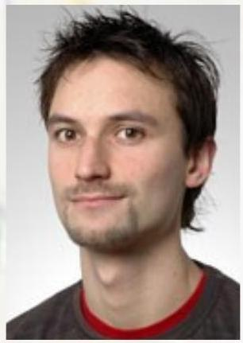

Benchmarking Human and Artificial Intelligence," co-sponsored by the IMS and Departments of Mathematics and Physics.

To use Sherson’s own words: "Artificial intelligence (AI) is a field is in rapid development and there are almost-daily news reports about how AI has revolutionized yet another industrial domain. Some researchers claim that within a few decades we will reach a socalled singularity in which computer intelligence will surpass human capabilities in all domains. Other AI-researchers, however, maintain that we have still far  
from understood the human ability to reach fast, intuitive and correct decisions based on often seemingly too little data. In the www.scienceathome.org project, we have developed games allowing so far 250,000 players to contribute to research in quantum and classical physics, mathematics, chemistry, behavioral economics, corporate management, psychology and cognitive science. We believe that this wealth of data from human individual and collective problem solving can be used to generate novel insights about human intuition and innovation that could potentially form the basis of novel forms of human-inspired AI.

Sherson concluded the talk with a description of how the work is situated "within the new global educational movement, Think Like a Scientist, in which we introduce citizen science games to the formal school setting at all levels as a means to make the world of research and knowledge generation available to the students from an early age."

## Virginia Mathematics Lecture Series

The Virginia Mathematics Lectures are a Distinguished Lecture Series that IMS established in 2014

### Spotlight: Yair Minsky

Yair Minsky of Yale University was our guest in mid-November and delivered three lectures as part of the Virginia Mathematics

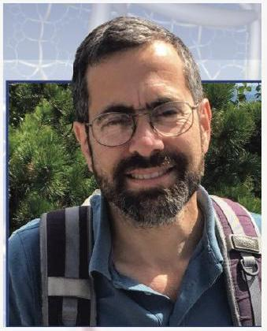

Lecture Series. The first lecture, "Hyperbolic $3$-manifolds, their structure and deformations," took place on November 13th, 2017. Minsky describes hyperbolic geometry as the "richest and most interesting of Thurston’s eight geometries for $3$-manifolds," explaining that "a good understanding of the ways in which hyperbolic geometry interacts with topology in three dimensions also informs our understanding of many related fields, such as geometric group theory and complex dynamics." The lecture served to provide "a brief introduction to this subject," with a focus on "examples, geometric intuition and overall structure."

The second lecture took place the following day, and was entitled "Between $2$ and $3$ dimensions: Teichmüller theory, pleated surfaces, and the complex of curves." "One can probe the geometry of a $3$-manifold," he continues, "by mapping in surfaces in different ways: conformal boundaries at infinity give us a parametrization of families of $3$-manifolds using classical Teichmüller space, and Thurston’s pleated surfaces relate the varying geometry on the interior to $2$-dimensional combinatorial and geometric structures." The lecture explored these ideas before moving on to a brief explanation of "how they provide a complete set of invariants for deformation spaces of $3$-manifolds."

The final lecture, "Quantitative models, Thurston’s skinning map, and beyond," occurred on November 15th. "While the theory has had many successes," Minsky concludes, "we are still far from having a complete ’effective’ recipe for predicting the geometry of a hyperbolic $3$-manifold from its topological description." Minsky then highlighted some current work being done in the area, as well as the unanswered questions that future work will need to address.

### Spotlight: Irene Fonseca

On March 15th and 16th, the Department was pleased to host Irene Fonseca of Carnegie Mellon University, who gave two talks on "Variational Methods for Materials and Imaging Sciences" as part of the Virginia Mathematics Lecture Series.

Fonseca explains that "recently developed methods and a deep articulation of ideas from the Calculus of Variations, Geometric Measure Theory, and nonlinear Partial Differential Equations (PDEs), have been instrumental in the mathematical rigorous understanding of nonlinear phenomena in a plethora of physical and technological applications, ranging from analyzing instabilities in novel advanced materials to the denoising of medical images."

### Undergraduate Experiences: AWM Lunch with Irene Fonseca

By Mia Shaker

On March 15, the UVA chapter of the AWM Math Department hosted a lunch with Professor Irene Fonseca from Carnegie Mellon University. Professor Fonseca is a renowned mathematician, the director of Carnegie Mellon’s Center for Nonlinear Analysis. She came to UVA to give a series of lectures on "Variational Methods for Materials and Imaging Sciences" in our "Virginia Mathematics Lecture Series" sponsored by the Institute for Mathematical Sciences. She also kindly agreed to meet with a group of the AWM members as well as the visiting admitted mathematics graduate students.

At the beginning of the event, Irene Fonseca shared a little bit about her research interests, and she heard from everyone in attendance about what their areas of interest in mathematics are.

But the real focus of the lunch and discussion was on the representation of women in mathematics. Irene Fonseca talked about her experience as the only female professor in the CMU math department, and how that has been true for almost the entirety of her 30 years teaching. It opened up a larger conversation about what the admitted graduate students had seen in regards to representation in their own schools.

Another interesting dimension to the issue of women in mathematics that Irene Fonseca raised is the "two-body problem," which refers to how spouses in academia often struggle to obtain jobs at the same university, or within commuting distance of each other. Fonseca, while having seen the two-body problem stop several women she knows from getting the best job available to them, felt that CMU originally hired her in large part because they were hiring her then-husband.

As an undergraduate in the AWM, I often focus on the representation of women among students, but this lunch really broadened my perspective and had me looking towards the future. I found myself inspired by the way Irene Fonseca and others like her have been striving to succeed in such a male-dominated field.

## Undergraduate Accomplishments

### Arun Kannan Becomes First Graduate of the Distinguished Major Program in Mathematics

By Andrei Rapinchuk

The 2017-18 academic year saw the department roll out the revamped Distinguished Major Program (DMP). The program provides an opportunity for math majors, typically during their 4th year, to work on a research project under the supervision of a faculty member. The

[figure not shown]

findings are then organized in the Distinguished Major Thesis and presented at a public defense.

The first graduate of the program was Arun Kannan who wrote his thesis, entitled *Characters of Projective Modules in the BGG Category $\mathcal{O}$ for General Linear Lie Superalgebras*, under the supervision of Professor Weiqiang Wang during his 3rd year. While working on the thesis, Arun had developed the understanding of representation theory of semisimple Lie  
algebras and superalgebras at the level of second year PhD students. Arun successfully defended his thesis on April 4, 2018 and was presented with the DMP Completion Certificate at the Math majors dinner. In his 4th year, Arun will pursue a Master’s Degree in mathematics.

### Sebastian Haney Awarded Goldwater Scholarship

Mathematics major Sebastian Haney, currently in his third year, was one of about 20 students in the nation selected to receive the 2018 Goldwater Scholarship.

The Goldwater Foundation awards the scholarships, which Congress established in 1986 to perennially honor the lifetime work of Senator Barry Goldwater, to college sophomores and juniors who "intend to pursue research careers in the

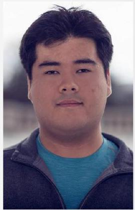

natural sciences, mathematics, and engineering."

## Gordon E. Keller Mathematics Majors Dinner

### E. J. McShane Prize in Mathematics, April 2018

The 2018 E. J. McShane Prize in Mathematics was given to Stephen Davis and Arun Kannan for their achievements in mathematics.

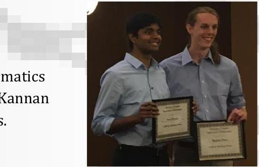

2018 E.J. McShane Prize winners

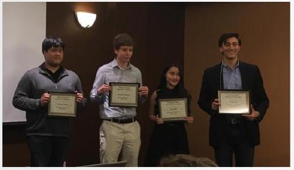

2018 Floyd Prize Winners

### Edwin E. Floyd Prize in Mathematics, April 2018

The 2018 Edwin E. Floyd Prize in Mathematics was awarded to Sebastian Haney, Benjamin Keigwin, Yichen Ma, and Ethan Zell. The prize is awarded to second- or third-year students who show exceptional promise in mathematics.

### Three Majors Elected into Phi Beta Kappa

Congratulations to Grace Dwyer, Kevin Lee, and Luca Scerbo! As the oldest and most distinguished honor society in the country, Phi Beta Kappa offers membership to less than one percent of all undergraduates. Many of the leading figures in American history and culture have begun their careers with election to the society, including seventeen presidents of the United States. As a result, membership is a remarkable accomplishment, both for the student who achieves it and the faculty and staff whose support and guidance has led to this milestone.

### Speaker: Angus Mitchell

The 2018 Gordon E. Keller Mathematics Majors Dinner, supported by a generous gift by Doug and Laurel Costa, took place last Spring. This year featured Angus Mitchell as our guest speaker, who lectured about data analytics. Angus graduated from UVA in 2013 with a degree in Financial Mathematics, as well as an interdisciplinary degree in Computer Science. He has had a dynamic career in the intervening years, including work with the NBA.

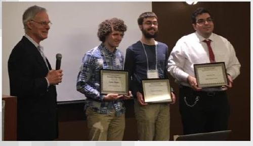

Ira Herbst with 2018 Putnam Award winners

### William Lowell Putnam Mathematical Competition Award, April 2018

The 2018 William Lowell Putnam Mathematical Competition Award was given to Emmett Dorlester, Zachary Baugher, and Luca Scerbo for their outstanding scores on the exam.

## Summer Research Program for Undergraduates

By Axel Saenz

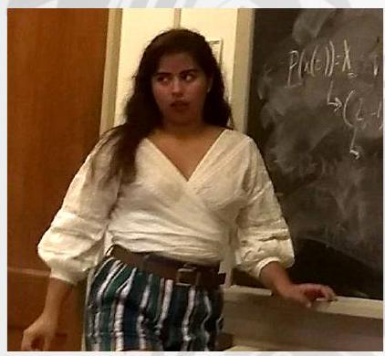

[figure not shown]

Program Participants and Organizers

The summer program was intended to bridge the gap between textbook mathematics and research-level mathematics showing the students that the subject is still evolving through an immersive first-hand research experience. Moreover, there was a strong emphasis in developing the communication skills of the students as it is often the case that the seemingly obtuse and technical language of research-level mathematics prevents beginners to express their ideas clearly. To this effect, the students were introduced to selected research problems in mathematics apt to their diverse academic backgrounds and were asked to tackle these problems through attentive advising of UVa math graduate students - Rostislav Akhmechet, Zachary Gates, Andrew Kobin, Mark Schrecengost, and Richard Vandenburgh- and postdocs - Prasit

Bhattacharya and Axel-Saenz Rodriguez.  
The program began with a one-week series of lectures and exercises led by the graduate students and postdocs. At the end of the first week, the students chose and were selected to create two research groups focusing on topics in group theory and probability theory, respectively. From then on out, the groups would

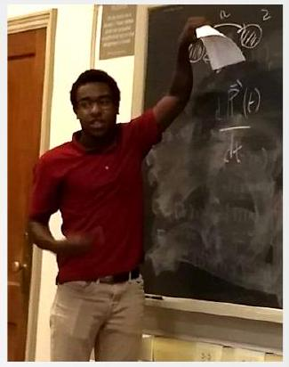

convene on a daily basis in the common areas of Kerchof Hall to carry out their research projects. This included independent readings, meetings with graduate and postdoc advisors, frequent presentations on the students’ progress, and weekly talks related to the research projects presented by faculty, postdocs, and graduate students. Throughout the summer, both the students and advisors were delighted by the experience as advisor Prasit Bhattacharya would comment that he was "... impressed by the level of depth and understanding the students were able to attain in one summer ..." and participant Ethan Zell would also remark that he "... enjoyed the camaraderie of the [summer program] and felt very productive."

## Reaching Out: Math Circles

*UVA Mathematics Professor, Graduate Students Introduce New Program to Inspire Talented, Young Mathematicians*

This article is reprinted with permission from Lorenzo Perez, the Senior Writer for the Dean’s Office of the College and Graduate School of Arts & Sciences. The photos are the work of Molly Angevine, A&S Communications Coordinator, and have been reprinted here with her permission.

It was only when Professor Slava Krushkal called for a short break that the 14 assembled students reverted back to elementary-school form. A few remained in  
pairs at their tables, dueling over graph paper as they played extra rounds of the Shannon switching game of strategy introduced earlier by Krushkal, a mathematics professor in UVA’s College and Graduate School of Arts & Sciences.

The talented mathematicians sat hunched over their calculations as they worked through a series of problems on an unseasonably warm Sunday afternoon last December. Sunlight streamed through the windows of the University of Virginia’s Charles L. Brown Science & Engineering Library, but no one, not even the small number cruncher wearing yellow soccer socks, shin guards and cleats, directed a wistful gaze outdoors as they wrestled with a triangular array of binomial coefficients known as Pascal’s Triangle.

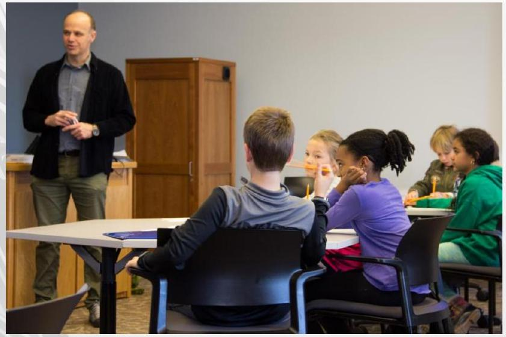

Math professor Slava Krushkal with 4th- and 5th-grade students

The rest gravitated to the wheelchair ramp at the far corner of the room, giggling as they took turns hanging over the railings now serving as their own personal jungle gym. "Graduate students will just sit down and work for hours on a problem, but I’ve learned that with kids, you have to entertain them and take breaks," Krushkal says.

### A Different Approach

Math-enrichment programs for interested young students are no longer uncommon in the United States. For the new Math Circle program that Krushkal launched last fall for 15 local 4th- and 5th-graders nominated by their schools, he looked for inspiration in his own educational experience growing up in Russia. As students achieved fluency in different mathematical concepts, the mathematics curriculum there stressed the importance of students honing their creativity as they think their way through increasingly difficult logic problems. The first Math Circles in the United States were organized by the Mathematical Sciences Research Institute in Berkeley, California. Today, there are more than 200 Math Circles around the country.

With the assistance of Gabriel Islambouli and Michael Reeks, two Ph.D. students in the Department of Mathematics, Krushkal organized a semester-long schedule of Sunday afternoon Math Circle sessions. Setting up the program, he received some guidance from the Curry School of Education, as well as from his faculty colleague and former Department of Mathematics chair, Craig Huneke.  
"We have many first-rate mathematicians at UVA, and the establishment of Math Circles allows us to use this talent to help K-12 students in our area," Huneke said. "It is enormously empowering for children to think actively about the solution of mathematical problems, and to develop the solution themselves. No matter what the future holds for the children who go through Math Circles, the lessons they learn in problem-solving and self-reliance will be invaluable for them."

The Math Circle program continued in Fall 2018. This year the program, taught by Slava Krushkal with the help of graduate students Peter Johnson and Rostislav Akhmechet, is geared towards 5th and 6th grade students from Charlottesville area schools.

Earlier in the fall, Krushkal, Islambouli and Reeks introduced the students to "Hex," a strategic game devised independently in the 1940s by two mathematicians, Piet Hein and John Nash. On another Sunday, Krushkal dipped the frame of a triangular pyramid, built with sticks, into a soap solution. After he pulled the tetrahedron-shaped frame out of the solution, the bubble created within the frame came together at a single point smack in the middle of the open frame. That led to a discussion explaining how bubbles seek stability by minimizing their surface area. Soon, students were crafting other polyhedra out of sticks to make different bubbles.  
"The bubbles are beautiful, and the students are saying, ’Wow!’, and then we discuss the mathematical principles underlying the experiment as we explain how the soap bubbles try to minimize area as they achieve the ultimate shape," Krushkal said.

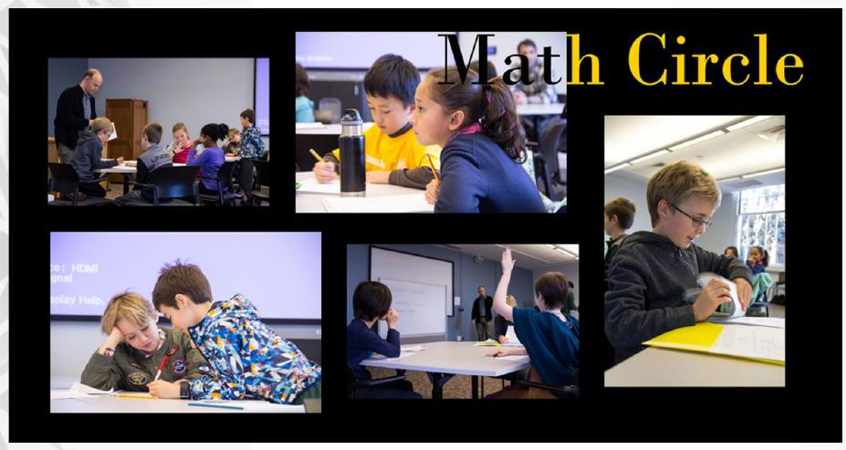

The UVA Math Circle took a break during the spring semester and was revived for the fall. Parents of the program’s initial class of students said their children are eager to continue in the Math Circle next school year.

Michael Garcia said that the Math Circle program provided his son, a 5th-grade student at Walker Elementary, an opportunity to meet other students his age who share his interest in learning math.  
"He was always eager to go and to share what he had learned," Garcia said. "I appreciated that he was given exposure to university faculty and students, introducing the idea that learning math is a long-term endeavor. The hands-on nature of the class really captured my son’s attention."

## Recent PhDs

### John Berman: Categorified Algebra and Equivariant Homotopy Theory

*Advisor: Michael Hill*

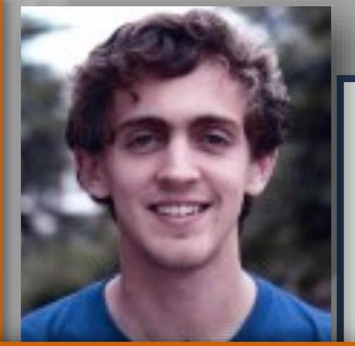

John Berman

Since the mid-twentieth century, algebraic topologists and algebraic geometers have used categories to organize rich algebraic structure. However, during all this time there have been hints that categories are not just organizational tools, but important algebraic objects in their own right.  
For example, algebraic invariants of a ring (including $K$-theory and Hochschild homology) are really invariants of the derived $\omega$-category $\operatorname{Mod}(R)$ of chain complexes of $R$-modules. This is the perspective of noncommutative motives, which have recently been developed by Blumberg, Gepner, Tabuada, and others [2]. The upshot is that noncommutative algebraic geometry should study stable $\infty$-categories [3], rather than rings or schemes.  
Noncommutative algebraic geometry shows promise in approaching long-standing problems related to the field with one element. While $\mathbb{F}_{1}$ has no meaning by itself, it is meaningful to speak of an $\mathbb{F}_{1}$-module (of which the simplest examples are finite sets). This area is related to major open problems: the Riemann Hypothesis is an $\mathbb{F}_{1}$-analogue of the Weil Conjectures, and the Hodge Conjecture is an $\mathbb{F}_{1}$-analogue of the Tate Conjecture.  
However, to study noncommutative motives over $\mathbb{F}_{1}$, we must study algebraic $\omega$-categories which are not necessarily stable. (There are also many other obstacles to studying $\mathbb{F}_{1}$ which we will not discuss.)  
With this application in mind, the goal of my thesis is to introduce new purely algebraic techniques to study $\omega$-categories, building on [1]. This philosophy is best illustrated by two theorems and a conjecture (which may also function as definitions):

**Theorem 1**. *An additive $\omega$-category is a module over the Burnside $\omega$-category (as a semiring $\omega$-category).*

**Theorem 2**. *A Lawvere theory is a cyclic module over $\operatorname{Fin}^{\mathrm{op}}$, the opposite category of finite sets.*

**Conjecture 1**. *An $\infty$-operad is a cyclic module over $\operatorname{Fin}^{\mathrm{op}}$ which is trivializable over Burn.*

Another potential application of these ideas is to equivariant homotopy theory. We will discuss the perspective that equivariance in homotopy theory arises from reparametrizing Lawvere theories over finite $G$-sets. Finally, we introduce the following conjecture. Although we cannot define all the terms in the conjecture, we do state and prove a weaker version.

**Conjecture 2**. *The $\infty$-categories of naive and genuine equivariant spaces are dual as noncommutative motives over $\mathbb{F}_{1}$.*

References  
[1] J. Berman. On the commutative algebra of categories. Submitted.  
[2] A. Blumberg, D. Gepner, and G. Tabuada. A universal characterization of higher algebraic K-theory. Geom. Topol. 17: 733–838 (2013).  
[3] J. Lurie. Higher Algebra. http://www.math.harvard.edu/~lurie/ (2011). Preprint.

### Kristin Courtney: $\mathrm{C}^{*}$-Algebras and Finite-Dimensional Representations

*Advisor: David Sherman*

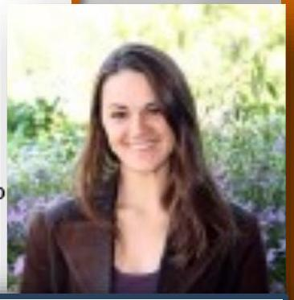

Kristin Courtney

$\mathrm{C}^{*}$-algebras and other operator algebras are typically infinite-dimensional; yet some have enough finite-dimensional representations to recover their structure. A $\mathrm{C}^{*}$-algebra with enough finite-dimensional representations is called residually finite-dimensional. My research studies characterizations and applications of this and related properties, often in connection with universal objects and lifting arguments.

**Definition 1**. A $\mathrm{C}^{*}$-algebra is Residually Finite-Dimensional (RFD) if it has a family of finite-dimensional representations whose direct sum forms an injection.

Before the property can be used, one must be able to identify whether a given $\mathrm{C}^{*}$-algebra is RFD. The following is a new characterization of residual finite-dimensionality in terms of the density of a distinguished subset of the $\mathrm{C}^{*}$-algebra.

**Theorem 3** (Courtney-Shulman). *A $\mathrm{C}^{*}$-algebra is RFD iff it contains a dense subset of elements that attain their norm under some finite-dimensional representation.*

Moreover, we can also characterize when this subset is the entire set.

**Theorem 4** (Courtney-Shulman). *For any $\mathrm{C}^{*}$-algebra $A$, the following are equivalent.*

1. *Every element in $A$ attains its norm under some finite-dimensional representation.*
2. *Every irreducible representation of $A$ is finite-dimensional.*
3. *The set of elements of $A$ that attain their norm under a finite-dimensional representation is an algebra.*

Residual finite-dimensionality can yield surprising results in surprisingly elegant ways. For example, we can use it to generalize a famous inequality of von Neumann to certain noncommutative polynomials in two variables.

**Theorem 5** (Courtney). For any noncommutative polynomial $p$ in two variables,
$$\sup \left\{\left\|p\left(T, T^{*}\right)\right\| : T \text{ a contractive Hilbert space operator}\right\} = \sup \left\{\left\|p\left(T, T^{*}\right)\right\| : T \text{ a nilpotent matrix}\right\}.$$

Moreover, we can connect this result to an infamous open conjecture of Alain Connes.

**Theorem 6** (Courtney). *The following conjectures are equivalent.*

1. *Connes’ Embedding Conjecture has a positive solution.*
2. *The universal unital $\mathrm{C}^{*}$-algebra generated by a pair of doubly commuting contractions is RFD.*
3. *The universal unital $\mathrm{C}^{*}$-algebra generated by a pair of doubly commuting contractions is RFD, and the separating family of representations can be chosen so that the generators map to nilpotent matrices.*

### Eloísa Grifo: Symbolic Powers, Containment, and Closure Operations

*Advisor: Craig Huneke*

Hilbert’s Nullstellensatz establishes a fundamental dictionary between geometry and algebra: the vanishing set of each radical ideal $I$ in $\mathbb{C}\left[x_{1}, \ldots, x_{n}\right]$ is an algebraic subvariety of $\mathbb{C}^{n}$ and this correspondence is bijective. By the classical Zariski-Nagata Theorem, the polynomials that vanish up to order $n$ along the variety defined by $I$ coincide with the $n$-th symbolic power of $I$. Symbolic powers arise naturally from the theory of primary decomposition.

**Definition 2**. Let $P$ be a prime ideal in a domain $R$. The $n$-th symbolic power of $P$ is the ideal given by
$$P^{(n)}=\left\{f \in R \mid gf \in P^{n} \text{ for some } g \notin P\right\} = P^{n} R_{P} \cap R.$$
This can be generalized to a definition for any radical ideal $I$.

It is natural to compare $I^{(n)}$ with the ordinary powers $I^{n}$. Even though $I^{n} \subseteq I^{(n)}$ always holds, we often have $I^{n} \neq I^{(n)}$. The Containment Problem asks when $I^{(a)} \subseteq I^{b}$. Over any regular ring, Ein-Lazarsfeld-Smith, Hochster-Huneke and Ma-Schwede showed that $I^{(hn)} \subseteq I^{n}$ for all $n \geqslant 1$, where $h$ is an invariant of $I$ known as the big height. Geometrically, the big height measures the largest codimension of an irreducible component of $I$.

**Conjecture 3** (Harbourne). *If $I$ is a radical ideal of big height $h$ in a regular ring, $I^{(hn-h+1)} \subseteq I^{n}$ for all $n$.*

Dumnicki, Szemberg and Tutaj-Gasińska showed that this fails for certain point configurations in $\mathbb{P}^{2}$. However, Harbourne’s Conjecture does hold for nice classes of ideals, such as those corresponding to points in general position in $\mathbb{P}^{2}$ and $\mathbb{P}^{3}$, or for squarefree monomial ideals.

**Theorem 7** (Grifo-Huneke). *Let $R$ be a regular ring of characteristic $p > 0$ (respectively, essentially of finite type over a field of characteristic 0), and let $I$ be an ideal in $R$. If $R/I$ is $F$-pure (respectively, of dense $F$-pure type), then $I$ verifies Harbourne’s Conjecture.*

The class of $F$-pure rings includes determinantal rings, Veronese rings and "nice" rings of invariants. These examples are all in fact strongly $F$-regular (respectively, have log-terminal singularities), and if we restrict to this subclass, this result can be improved, replacing $h$ by $h-1$. If $h=2$, this gives $I^{n}=I^{(n)}$.

Harbourne’s Conjecture is as a generalization of an open question of Huneke: given a prime ideal $P$ of height 2, must $P^{(3)} \subseteq P^{2}$? We show that this holds for the defining ideal of $k\left[t^{a}, t^{b}, t^{c}\right]$ in $k[x, y, z]$.

There is also evidence that Harbourne’s Conjecture might always hold for all $n \gg 0$.

**Theorem 8** (Grifo). *Let $I$ be a radical ideal of big height $h$ in a regular ring containing a field. If $I^{(hm-h)} \subseteq I^{m}$ for some $m \geqslant 2$, then $I^{(hn-h)} \subseteq I^{n}$ for all $n \gg 0$.*